# Python Coursework

### Student Number : 27016005

### Date : Pre 07/12/2020

### Actual hrs spent for the assignment: 50+

#### **CSGitLab Link:** *https://csgitlab.reading.ac.uk/br016005/python-for-data-science-coursework/-/tree/master/*

### Assignment evaluation :

###### - More guidance could have been given on what was expected to be contained in the final submission.

###### - More guidance could have been given on what tools we were expected to use (E.G. Seaborn vs MatPlotLib)

While i know both of these points were deliberate to an extent, a more defined project proposal is always appreciated.

###### - The assignment was interesting, useful and applicable to real world applications.

The assignment allowed us to demonstrate skill which would be useful and applicable in a workplace environment. Further more the assignment was well established and the relative skills were taught effectively thoughout the course.

side note: Each task was originally completed in a separate Jupyter notebook, if any of the code seems to fail or parts seem missing, these notebooks are available at the CSGitLab Repository given above.

# Task 1 - Bike Journey Exploratory Data Analysis

### Key Points to Note:

#### **Bike journey data**

This data set contains anonymised bike trip data from the Los Angeles Metro Bike Share, available here: *https://bikeshare.metro.net/about/data/*. Use the metro.csv data file provided in the CSGitLab Repository. Each row corresponds to a single bike journey. The columns in the data are:

- **trip_id:** Locally unique integer that identifies the trip duration Length of trip in minutes.
- **start_time:** The date/time when the trip began, presented in ISO 8601 format in local time 1.
- **end_time:** The date/time when the trip ended, presented in ISO 8601 format in local time.
- **start_station:** The station ID where the trip originated.
- **start_lat:** The latitude of the station where the trip originated.
- **start_lon:** The longitude of the station where the trip originated.
- **end_station:** The station ID where the trip terminated.
- **end_lat:** The latitude of the station where the trip terminated.
- **end_lon:** The longitude of the station where the trip terminated.
- **bike_id:** Locally unique integer that identifies the bike.
- **plan_duration:** The number of days that the plan the passholder is using entitles them to ride.
- **trip_route_category:** "Round Trip" for trips starting and ending at the same station or "One Way" for all other trips.
- **passholder_type:** The name of the passholder’s plan.
- **bike_type:** The kind of bike used on the trip, including standard pedalpowered bikes, electric assist bikes, or smart bikes.

```python
import warnings
warnings.filterwarnings('ignore')
```

### Importing Necessary modules, Libraries etc, Seting Base Directory location. Load CSV

If attempting to run this code, please note the following block will need to be changed.

- **BASE_DIR** : The folder where the datasets are stores, this must be downloaded onto the local machine and unzipped. This must contain all 3 of the datasets (metro.csv, seeds.csv, social-network.csv). This may need to be changed to where the folder is located on the machine attempting to run the code.
- **Metro** : This is reading the **"metro.csv"** from inside the folder stated above. This means the "metro.csv" must remain in the folder defined above, alternatively, a full filepath could be given here, directing straight to the CSV.

N.B. Filepaths must be declared relative to the system. On Windows, file paths use the "/" or "\\" separator, on unix machines use "/".

```python
import pandas as pd
#NOTE This will need to be changed to location of folder all files are in.
BASE_DIR = 'D:/Users/Danny/FROM C/Desktop/Datasets'

Metro = pd.read_csv(BASE_DIR+'/metro.csv')                  # Should use os.path.join() here
############################################################# pDF = pd.DataFrame(data = pd.read_csv(BASE_DIR+'/metro.csv'))
Metro.head()
```

|  | trip_id | duration | start_time | end_time | start_station | start_lat | start_lon | end_station | end_lat | end_lon | bike_id | plan_duration | trip_route_category | passholder_type | bike_type |
| --- | --- | --- | --- | --- | --- | --- | --- | --- | --- | --- | --- | --- | --- | --- | --- |
| 0 | 124657107 | 5 | 7/1/2019 0:04 | 7/1/2019 0:09 | 4312 | 34.066990 | -118.290878 | 4410 | 34.063351 | -118.296799 | 6168 | 30 | One Way | Monthly Pass | standard |
| 1 | 124657587 | 9 | 7/1/2019 0:07 | 7/1/2019 0:16 | 3066 | 34.063389 | -118.236160 | 3066 | 34.063389 | -118.236160 | 17584 | 30 | Round Trip | Monthly Pass | electric |
| 2 | 124658068 | 5 | 7/1/2019 0:20 | 7/1/2019 0:25 | 4410 | 34.063351 | -118.296799 | 4312 | 34.066990 | -118.290878 | 18920 | 30 | One Way | Monthly Pass | electric |
| 3 | 124659747 | 20 | 7/1/2019 0:44 | 7/1/2019 1:04 | 3045 | 34.028511 | -118.256668 | 4275 | 34.012520 | -118.285896 | 6016 | 1 | One Way | Walk-up | standard |
| 4 | 124660227 | 27 | 7/1/2019 0:44 | 7/1/2019 1:11 | 3035 | 34.048401 | -118.260948 | 3049 | 34.056969 | -118.253593 | 5867 | 30 | One Way | Monthly Pass | standard |

This Shows the set up and initialisation for the analysis and data handling which is to be undertaken. An open source data analsis and manipulation tool called **"Pandas"** is imported for aid of manipulation. The base directory for the all data sets used is given in **"BASE_DIR"** and then the dataset used for this experimentation is read from a csv and converted into a dataframe with the alias **"Metro"**.

The **".head()"** function is then used to display the first 5 records in the data frame. At this stage, this is purely for the reader's benefit.

For more information on the **Pandas tool** - see the official site and documentation: *https://pandas.pydata.org/*

### Find a sensible way to remove the missing values from the data frame and explain why you have chosen this method.

Two methods of counteracting the missing values in the data set, are by either dropping any records (rows) that have missing values, or by filling them with an arbitrary value - 0 is the value usually chosen however this will significantly effect all of the statistical calculations done on the data. A way of improving this could be to fill with the mean value for that column instead, however this will still affect the statistics, for example if a group of data (in this case something like bike_type) had a significantly lower mean than another subgroup filling missing values with the overall mean would skew the distribution of the subgroups, meaning any cross comparison would be heavily affected.

For this reason - The best course of action was to determine where the missing data lies and what how these the processes would affect the overall results.

The method used to check this, was first performing a count on the amount of cells records which contained data for each field, and also to count which fields were affected by the missing data, how much of the data was missing for each field and what effect that could have overall on the statistics.

The **".count()"** function was used to show how many records held data for each field. (**'Metro'** is the name of the dataframe used). This also gives a good estimate at the total amount of records in the dataset (relying on data not missing in every column). In an ideal situation with no missing data, all of the following values should be the same.

```python
Metro.count()
```

```
trip_id                92124
duration               92124
start_time             92124
end_time               92124
start_station          92124
start_lat              89985
start_lon              89985
end_station            92124
end_lat                88052
end_lon                88052
bike_id                92124
plan_duration          92124
trip_route_category    92124
passholder_type        92124
bike_type              92124
dtype: int64
```

From first glance, it can be inferred that there are probably 92124 records, however this is not necessarily the case, so further checks must be made, just to be safe.  
A way to enquire more information about the data would be to use the **".info()"** function, which will show the file types and amount of data in each field, as well as the index and name of each column.

```python
Metro.info()
```

```
<class 'pandas.core.frame.DataFrame'>
RangeIndex: 92124 entries, 0 to 92123
Data columns (total 15 columns):
 #   Column               Non-Null Count  Dtype
---  ------               --------------  -----
 0   trip_id              92124 non-null  int64
 1   duration             92124 non-null  int64
 2   start_time           92124 non-null  object
 3   end_time             92124 non-null  object
 4   start_station        92124 non-null  int64
 5   start_lat            89985 non-null  float64
 6   start_lon            89985 non-null  float64
 7   end_station          92124 non-null  int64
 8   end_lat              88052 non-null  float64
 9   end_lon              88052 non-null  float64
 10  bike_id              92124 non-null  object
 11  plan_duration        92124 non-null  int64
 12  trip_route_category  92124 non-null  object
 13  passholder_type      92124 non-null  object
 14  bike_type            92124 non-null  object
dtypes: float64(4), int64(5), object(6)
memory usage: 10.5+ MB
```

Next a combination of the **".isna()"** - which is a check to see if the field is null for that record, plus the **".sum()"** function which sums the results, were used to calculate the amount of missing records for each field. As shown in the discrepancies above, it is expected that there will be many missing entries for the **"start_lat"**, **"start_lon"**, **"end_lat"**, **"end_lon"** - however it is important to check there are no missing entries in the other fields too. For example, the other fields could all be missing the same amount of entries, distributed amongst different records. This would change how the data needs to be manipulated.

```python
Metro.isna().sum()
```

```
trip_id                   0
duration                  0
start_time                0
end_time                  0
start_station             0
start_lat              2139
start_lon              2139
end_station               0
end_lat                4072
end_lon                4072
bike_id                   0
plan_duration             0
trip_route_category       0
passholder_type           0
bike_type                 0
dtype: int64
```

This confirms the assumption that there are **92124** records and only the four fields previously mention contain missing data.

Due to the size of the dataset, it would be more than reasonable to drop any records with missing data, this would still leave 88052 (over 95% of the data) records to analyse and manipulate.

However, upon further analysis of the data, and the analysis methods and manipulations that will be used on the data, including what information is intended to be represented and gathered from the dataset, it can be seen that these fields hold little-to-no relevance and significance to the overall statistical analysis and operations performed, therefore a more suitable option would be to fill these missing values with an arbitrary value.

The value of '0' was chosen for this.  
The Function **".fillna(0)"** was used to fill any null fields with the value of **'0'**.

```python
fillMetro = Metro.fillna(0)
```

To show the cells have been filled: **"fillMetro.isna().sum()"** was run again:

```python
fillMetro.isna().sum()
```

```
trip_id                0
duration               0
start_time             0
end_time               0
start_station          0
start_lat              0
start_lon              0
end_station            0
end_lat                0
end_lon                0
bike_id                0
plan_duration          0
trip_route_category    0
passholder_type        0
bike_type              0
dtype: int64
```

This shows there are now no records with any data missing in any fields.

### Libraries and preparation for plotting any graphs or visuals.

First all of the libraries and tools that will be used to process and represent the data throughout will be imported here: Note: Pandas has already been imported so no repeat here.

```python
%matplotlib inline
from matplotlib import pyplot as plt
import seaborn as sns
```

To display the plots in the Jupyter Notebook **"%matplotlib inline"** must be included.

For more information on the **matplotlib** libraries and **pyplot**- see the official site and documentation *https://matplotlib.org/tutorials/introductory/pyplot.html*

For the code and further information visit the GitHub Repository: *https://github.com/matplotlib/matplotlib*

**seaborn** - *"**Seaborn** is a **Python** data visualization library based on **matplotlib**. It provides a high-level interface for drawing attractive and informative statistical graphics."* *"**Seaborn** is a library for making statistical graphics in **Python**. It builds on top of **matplotlib** and integrates closely with **pandas** data structures."*

For more information on the **Seaborn** - see the official site and documentation: *https://seaborn.pydata.org/*

For the code and further information visit the GitHub Repository: *https://github.com/mwaskom/seaborn*

### Explore the distribution of the duration variable. You should produce a plot visualising the distribution and calculate and briefly discuss statistics of the variable.

```python
print("FillMetro:")
fillMetro['duration'].describe()
```

```
FillMetro:
```

```
count    92124.000000
mean        33.168588
std        129.057841
min          1.000000
25%          6.000000
50%         12.000000
75%         22.000000
max       1440.000000
Name: duration, dtype: float64
```

Returns all of the relevant values for the entire dataset regarding the duration column. This includes the: **Count(total)**, **Mean**, **Standard Deviation**, **Minimum value**, **Lower Quartile value**, **Median value**, **Upper Quartile value**, and **Maximum**.

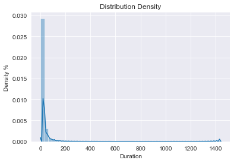

```python
##fillMetro['duration'].hist(( bins=30, normed=True, alpha=0.5,
  #       histtype='stepfilled', color='steelblue',
  #       edgecolor='none'))
sns.set_style('darkgrid')
ax = sns.distplot(fillMetro['duration'], label = "Duration Distribution")
ax.set(xlabel = "Duration", ylabel = "Density %", title = "Distribution Density")
plt.show()
```

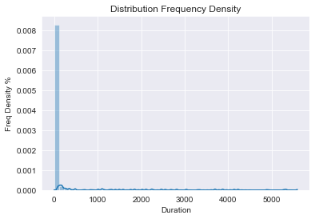

```python
ax = (sns.distplot(fillMetro['duration'].value_counts()))
ax.set(xlabel = "Duration", ylabel = "Freq Density %", title = "Distribution Frequency Density")
plt.show()
```

The data was also interpretted as a histogram in an attempt to gather more information about the data set - however this did not yield much results which were of use to the investigation. A more suitable, similar style of graph, was the Seaborn 'Distplot', this opts for a histogram style graph with a Kernel Density Estimate (KDE) overlay.

### Produce a plot showing how the distribution of duration relates to passholder_type.

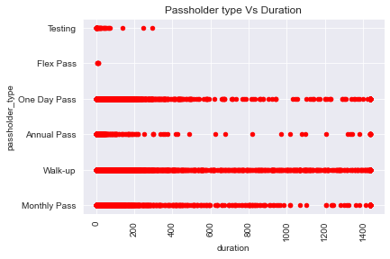

```python
# Counting the values within 'duration'
barDuration = fillMetro['duration'].value_counts(sort = True)

# Plotting a bar chart
fillMetro.plot.scatter(title  = "Passholder type Vs Duration", x = 'duration', y = 'passholder_type', rot = 90, color = 'red')
#fillMetro.plot.bar()
```

The annual pass shows a diverse spread of duration trips, although the annual pass shows a higher concentration around the 0-200 range and a lower focus around the 200-400 range than the other passes, it still has users who take trips of all durations from extremely quick (0-20) all the way up extremely long (1400+) with a few at various intervals inbetween. The walk up pass is by far the most popular choice for the people who prefer to take longer trips, and the second most popular overall, the distribution of duration for the walkup pass is much more evenly distributed when compared to the one day pass, which has a intense concentration around shorter trips; the walk up trip has a consistent volume of people taking trips of all lengths, and clearly dominates the other pass options for any trips above 600 in duration.

To further validate these claims, more variations of representations of data were used, a box and whisker diagram was used to show the interquartile range, the suspected outliers and the median. The whiskers stop at the relative quartile ± the 1.5 x the interquartile range. This is extremely useful for seeing where the majority of the data lies. As expected, the majority of all the data is in the shortest duration segment. However the graphical representation of the medians becomes extremely useful when comparing the spread of data.

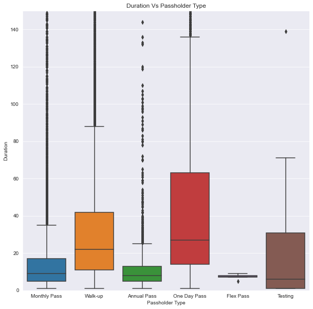

```python
Dims = (10,10)
#plt.axis([0,0, 150, 5000])
fig, ax = plt.subplots(figsize=Dims)
#sns.load_dataset(dropMetro)
ax.axis([0,0, 0, 150])
ax = (sns.boxplot(ax = ax, data = fillMetro, x = "passholder_type", y = "duration"))
ax.set(xlabel = "Passholder Type", ylabel = "Duration", title = "Duration Vs Passholder Type")
plt.show()
```

By using a Box & Whisker diagram and zooming in to the most active range, a large amount of information can be inferred. This figure clearly demonstrates the spread of the data. The diagram accurately represents the **median**, **interquartile range (upper quartile - lower quartile)** and the **"outlying"** data. The 'whiskers' show where the data lies within 1.5 times the interquartile range - of the interquartile range. For example, where *IQR = Q3 - Q1*, the upper 'whisker' will terminate at *Q3 + 1.5IQR* while the lower 'whisker' will terminate at *Q1 - 1.5IQR* OR **0** as this data cannot be negative.

The diagrams allow easy visual comparisons of **medians**, **Upper quartile values**, **Lower quartile values** and **general spread** and **density/dispersement** of data.

From this, many of the previous hypothesis have been confirmed, showing that while **0 - 150** is by far the most popular duration of the trip, encompassing the core majority of data (*from Q1 - IQR >-to-> Q3 + IQR* ) for every type of pass. It is apparent that those opting for longer trips tended towards the one day pass, or possibly the walk-up pass, while those opting for the annual or monthly pass stuck to shorter journeys on average.

Next a strip plot was used, this functions similarly to a scatterplot while also making the data much easier to interpret and showing the density much clearer. Overall this is probably the most useful plot for representing this data in a useful and significant manner. It accurately shows the density and concentration of each passholder type and allows easy interpretation of the spread of the data,

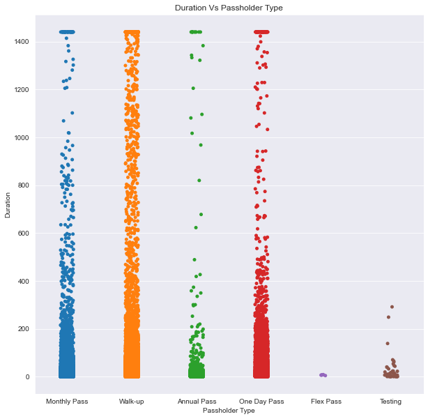

```python
Dims = (10,10)
fig, ax = plt.subplots(figsize=Dims)
ax =(sns.stripplot(ax = ax, data = fillMetro, x = "passholder_type", y = "duration"))
ax.set(xlabel = "Passholder Type", ylabel = "Duration", title = "Duration Vs Passholder Type")
plt.show()
```

### Convert the start_time and end_time columns to date objects if they are not already.

```python
DateDM = fillMetro
DateDM['start_time']= pd.to_datetime(DateDM['start_time'], format = '%m/%d/%Y %H:%M')
DateDM['end_time'] = pd.to_datetime(DateDM['end_time'])
DateDM[['start_time','end_time']].info()
```

```
<class 'pandas.core.frame.DataFrame'>
RangeIndex: 92124 entries, 0 to 92123
Data columns (total 2 columns):
 #   Column      Non-Null Count  Dtype
---  ------      --------------  -----
 0   start_time  92124 non-null  datetime64[ns]
 1   end_time    92124 non-null  datetime64[ns]
dtypes: datetime64[ns](2)
memory usage: 1.4 MB
```

Converting the given field for start time in column "**start_time**" from string format to datetime object - given in *yyyy-mm-dd HH:MM:SS* using: "**DateDM['start_time']= pd.to_datetime(DateDM['start_time'], format = '%m/%d/%Y %H:%M')**"

Repeating the process for the field for end time in column "**end_time**" "**DateDM['end_time'] = pd.to_datetime(DateDM['end_time'])**"

"**DateDM[['start_time','end_time']].info()**" is used to show the new types of these columns, these were both shown as type "*object*" in the initial call of this "**.info()**" function, before any manipulation had been performed on the data. This now shows them both as type "*datetime64*". Only these fields have been shown as the rest remain unchanged.

"**DateDM.head()**" is then used to show the first 5 columns of the new DataFrame - showing that the changes have been made.

```python
DateDM.head()
```

|  | trip_id | duration | start_time | end_time | start_station | start_lat | start_lon | end_station | end_lat | end_lon | bike_id | plan_duration | trip_route_category | passholder_type | bike_type |
| --- | --- | --- | --- | --- | --- | --- | --- | --- | --- | --- | --- | --- | --- | --- | --- |
| 0 | 124657107 | 5 | 2019-07-01 00:04:00 | 2019-07-01 00:09:00 | 4312 | 34.066990 | -118.290878 | 4410 | 34.063351 | -118.296799 | 6168 | 30 | One Way | Monthly Pass | standard |
| 1 | 124657587 | 9 | 2019-07-01 00:07:00 | 2019-07-01 00:16:00 | 3066 | 34.063389 | -118.236160 | 3066 | 34.063389 | -118.236160 | 17584 | 30 | Round Trip | Monthly Pass | electric |
| 2 | 124658068 | 5 | 2019-07-01 00:20:00 | 2019-07-01 00:25:00 | 4410 | 34.063351 | -118.296799 | 4312 | 34.066990 | -118.290878 | 18920 | 30 | One Way | Monthly Pass | electric |
| 3 | 124659747 | 20 | 2019-07-01 00:44:00 | 2019-07-01 01:04:00 | 3045 | 34.028511 | -118.256668 | 4275 | 34.012520 | -118.285896 | 6016 | 1 | One Way | Walk-up | standard |
| 4 | 124660227 | 27 | 2019-07-01 00:44:00 | 2019-07-01 01:11:00 | 3035 | 34.048401 | -118.260948 | 3049 | 34.056969 | -118.253593 | 5867 | 30 | One Way | Monthly Pass | standard |

### Create a new column in the data frame that gives the hour of the day that each journey started on.

```python
#addHour =
addHourDM = DateDM
addHourDM['startHour'] = pd.to_datetime(DateDM['start_time']).dt.hour
addHourDM.head()
```

|  | trip_id | duration | start_time | end_time | start_station | start_lat | start_lon | end_station | end_lat | end_lon | bike_id | plan_duration | trip_route_category | passholder_type | bike_type | startHour |
| --- | --- | --- | --- | --- | --- | --- | --- | --- | --- | --- | --- | --- | --- | --- | --- | --- |
| 0 | 124657107 | 5 | 2019-07-01 00:04:00 | 2019-07-01 00:09:00 | 4312 | 34.066990 | -118.290878 | 4410 | 34.063351 | -118.296799 | 6168 | 30 | One Way | Monthly Pass | standard | 0 |
| 1 | 124657587 | 9 | 2019-07-01 00:07:00 | 2019-07-01 00:16:00 | 3066 | 34.063389 | -118.236160 | 3066 | 34.063389 | -118.236160 | 17584 | 30 | Round Trip | Monthly Pass | electric | 0 |
| 2 | 124658068 | 5 | 2019-07-01 00:20:00 | 2019-07-01 00:25:00 | 4410 | 34.063351 | -118.296799 | 4312 | 34.066990 | -118.290878 | 18920 | 30 | One Way | Monthly Pass | electric | 0 |
| 3 | 124659747 | 20 | 2019-07-01 00:44:00 | 2019-07-01 01:04:00 | 3045 | 34.028511 | -118.256668 | 4275 | 34.012520 | -118.285896 | 6016 | 1 | One Way | Walk-up | standard | 0 |
| 4 | 124660227 | 27 | 2019-07-01 00:44:00 | 2019-07-01 01:11:00 | 3035 | 34.048401 | -118.260948 | 3049 | 34.056969 | -118.253593 | 5867 | 30 | One Way | Monthly Pass | standard | 0 |

This was achieved by using the inbuilt function in the **pandas** tool "**pd.to_datetime().dt.hour**" to extract the hour from the already formatted '**start_time**' column and then copy it into a new column named '**startHour**'.

### Explore how the duration variable varies between each journey starting hour of the day, creating a plot to visualise this

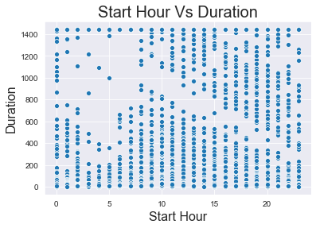

```python
sns.scatterplot(addHourDM['startHour'], addHourDM['duration'])
plt.xlabel("Start Hour", size=16)
plt.ylabel("Duration", size=16)
plt.title("Start Hour Vs Duration", size=20)
```

Plotting a scatterplot of Start hour Vs Duration is a great way to visualise the distribution of duration, however it quite chaotic due to the sheer amount of data points plotted. it also makes it harder to interpret because it is very hard to see the concentration of volume of the points plotted. For this reason, a more interpretable option was chosen, in the form of a bar plot of the mean duration for each start hour.

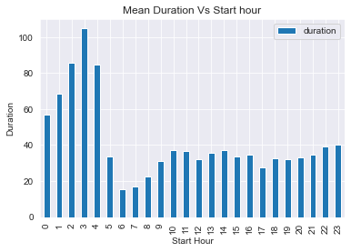

```python
#A plot showing the connection between duration and pass type
bar = addHourDM.groupby('startHour')
ax =(bar[['duration']].mean().plot.bar())
ax.set(xlabel = "Start Hour", ylabel = "Duration", title = "Mean Duration Vs Start hour")
plt.show()
```

This clearly shows the mean Duration of a trip depending on the hour of the day which the journey commenced at. It clearly shows that any journeys started between 00:00 and 04:59 are much more likely to be longer journeys, averaging over 55 minutes, whereas any journeys made initiated between 05:00 and 09:59 are likely to be much shorter, with average peaking below 37 minutes and average troughing below 20 minutes, and any journeys between 10:00 and 23:59 maintain a moderately constant average of around 38 minutes. From a logistical point of view this makes complete sense, as those embarking on a longer journey would be more inclined to start in the early hours, those between 05:00 and 09:00 are more than likely completing a quick morning exercise and would need to keep it short in order to make it back in time for their jobs, and those starting throughout the late morning-afternoon would be more likely to be taking a casual, comfortable trip.

# **Explore the distribution of the bike type. What kind of bike is more popular?**

### Numerical and Objective Analysis

For an objective numeric analysis, a count was performed on each type of bike.

```python
BikeDistroDM= addHourDM['bike_type'].value_counts(sort = True)
BikeDistroDM
```

```
electric    46446
standard    29477
smart       16201
Name: bike_type, dtype: int64
```

### Visual and Relative Analysis

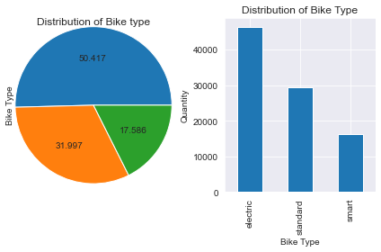

```python
plt.subplot(1, 2, 1)
#plt.figure(figsize=(10,10))
plt.pie(BikeDistroDM,autopct='%.3f', radius = 1.3)
plt.title('Distribution of Bike type')
plt.ylabel('Bike Type')


plt.subplot(1, 2, 2)
BikeDistroDM.plot.bar()
plt.xlabel('Bike Type')
plt.ylabel('Quantity')
plt.title("Distribution of Bike Type")
plt.tight_layout()
plt.show()


#ax = (BikeDistroDM.plot.pie(autopct='%.3f'))

#ax.set(ylabel = "Bike Type", title = "Distribution of Bike Type")
#plt.show()
```

[ For dropMetro values are as follows: Electric 52.81%, Standard 33.39%, Smart 13.8%  
this would imply many of the missing records were on smart bikes.]

# Explore how the distribution of the duration variable varies between each day of the week and by bike type, creating plots to visualise this. Discuss the results

A Pie Chart is an extrememly effective way of representing a relative view of distribution. Although the intended information to be gathered, is the distribution of duration relative to this variables - useful information to know is the genral distribution of these variables. As shown above, the distribution of 'bike_type' is already known, so the next logical step is to represent the distribution of the weekdays. This is shown below, again in both pie and bar chart formats.

### Distribution of Day of the week by frequency

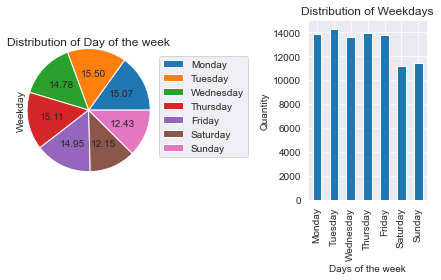

```python
#dotw = DateDM
dotw= ((pd.to_datetime(DateDM['start_time']).dt.weekday)).value_counts(sort = False)
plt.subplot(1, 2, 1)
labels = ['Monday', 'Tuesday', 'Wednesday', 'Thursday', 'Friday', 'Saturday', 'Sunday']
#plt.figure(figsize=(10,10))
plt.pie(dotw,autopct='%.2f', radius = 1.3)
plt.title('Distribution of Day of the week')
plt.ylabel('Weekday')
plt.legend(labels, bbox_to_anchor=(1.05, 1),)


plt.subplot(1, 2, 2)
ax= (dotw.plot.bar())
plt.xlabel("Days of the week")
plt.ylabel('Quantity')
ax.set_xticklabels(labels)
plt.title("Distribution of Weekdays")
plt.tight_layout()
plt.show()
```

As shown clearly above, they quantity of trips is fairly evenly distributed throughout monday to friday, each with around 15%( ± 0.5%) however, a drop to around 12.25%( ± 0.25%) is visible for saturday and sunday.

## Distribution of Duration relative to Bike type and Day of the week.

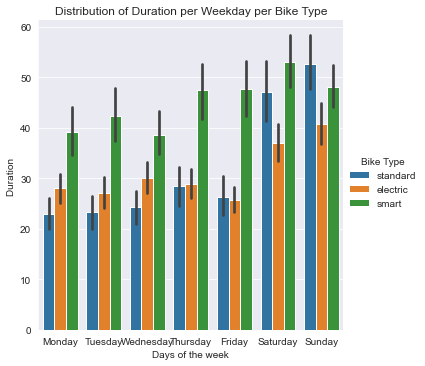

```python
DayBikeDist = DateDM
DayBikeDist['dotw'] = (pd.to_datetime(DateDM['start_time']).dt.weekday)
ax = sns.catplot(x = 'dotw', y= 'duration', hue = 'bike_type', data = DayBikeDist, kind = 'bar')
plt.xlabel("Days of the week")
plt.ylabel('Duration ')
plt.title("Distribution of Duration per Weekday per Bike Type")
ax._legend.set_title("Bike Type")
ax.set_xticklabels(labels)
```

This graph effectively shows the mean duration of each trip for each bike type, relative to the day of the week the trip commenced on. The graph clearly shows on average that smart bikes are the most popular choice for longer duration journeys. The graph also shows the average duration increases significantly at the weekends when compared to journeys between Monday and Friday. The graph displays a fairly consistent usage of each bike relative to each other during the week, however at weekends the standard bicycle becomes more popular than the electric bike,and even more than the smart bike on sundays. This is a clear representation of the distribution of duration relative to both the bike type and day of the week.

# Calculate the total numbers of passholders of each type travelling on each weekday. Discuss the results.

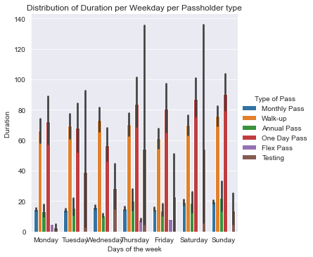

```python
dayVsPass = DateDM#.groupby('dotw')

dayVsPass.describe()
ax = sns.catplot(x = 'dotw', y= 'duration', hue = 'passholder_type', data = dayVsPass, kind = 'bar')
plt.xlabel("Days of the week")
plt.ylabel('Duration ')
plt.title("Distribution of Duration per Weekday per Passholder type")
ax._legend.set_title("Type of Pass")
ax.set_xticklabels(labels)
```

This graph shows the mean duration of a trip, relative to the pass that was used, and the day which the trip started on. This is good for a visual interpretation of the distribution of duration relative to passholder type and weekday. This is not quite the frequency of passholders Vs weekday, however it does offer an insight into the data and distribution.

```python
labels = ['Monday', 'Tuesday', 'Wednesday', 'Thursday', 'Friday', 'Saturday', 'Sunday']
tab = (pd.crosstab(DateDM['dotw'], DateDM['passholder_type']))
tab.index = labels
print("Table showing ->  WeekDay Vs Passholder Type: ")
tab
```

```
Table showing ->  WeekDay Vs Passholder Type:
```

| passholder_type | Annual Pass | Flex Pass | Monthly Pass | One Day Pass | Testing | Walk-up |
| --- | --- | --- | --- | --- | --- | --- |
| Monday | 1046 | 1 | 9322 | 522 | 5 | 2991 |
| Tuesday | 1081 | 0 | 9570 | 557 | 5 | 3065 |
| Wednesday | 1082 | 0 | 9099 | 579 | 6 | 2846 |
| Thursday | 976 | 4 | 8999 | 669 | 7 | 3267 |
| Friday | 994 | 1 | 8676 | 765 | 5 | 3336 |
| Saturday | 560 | 0 | 5603 | 1029 | 6 | 3997 |
| Sunday | 481 | 0 | 5906 | 1054 | 12 | 4000 |

What can be inferred from this table:

# Mark Scheme: ✅❌

- An exceptional understanding of the principles of data modelling. ✅
- Professional use of modelling notation(s). ✅
- Excellent technical skills in implementing and testing a database model.✅
- Clear presentation of the coursework.✅
- Load the metro.csv file into a Pandas data frame.✅
- Find a sensible way to remove the missing values from the data frame and explain why you have chosen this method. ✅
- Explore the distribution of the duration variable. You should produce a plot visualising the distribution and calculate and briefly discuss statistics of the variable. ✅
- Produce a plot showing how the distribution of duration relates to passholder_type.✅
- Convert the start_time and end_time columns to date objects if they are not already.✅
- Create a new column in the data frame that gives the hour of the day that each journey started on.✅
- Explore how the duration variable varies between each journey starting hour of the day, creating a plot to visualise this.✅
- Explore the distribution of the bike type. What kind of bike is more popular?✅
- Explore how the distribution of the duration variable varies between each day of the week and by bike type, creating plots to visualise this. Discuss the results.✅
- Calculate the total numbers of passholders of each type travelling on each weekday. Discuss the results✅

# Task 2 - Data Clustering - Seed Shape Data

# research and implementation:

## Context for the dataset

Data sourced from: UCI machine learning repository, originally by M. Charytanowicz, J. Niewczas, P. Kulczycki, P.A. Kowalski, S. Lukasik, S. Zak in ‘A Complete Gradient Clustering Algorithm for Features Analysis of X-ray Images’, in: Information Technologies in Biomedicine, Ewa Pietka, Jacek Kawa (eds.), Springer-Verlag, Berlin-Heidelberg, 2010, pp. 15-24. 2

Available here: *https://archive.ics.uci.edu/ml/datasets/seeds#*. Use the seeds.csv data file provided in the CSGitLab Repository.

This data set contains measurements of seeds from a number of different plant species. Each row corresponds to a single seed. The columns are:

- **area**: The area of the seed.
- **Perimeter**: The length of the perimeter of the seed.
- **Compactness**: A measure of the area of the seed relative to the perimeter.
- **Length**: The length of the seed.
- **Width**: The width of the seed.
- **Asymmetry**: A measure of the asymmetry of the seed.
- **groove length**: The length of the groove in the seed.

  *Note: In the dataset provided, the column containing the correct classification of the kernel has been omitted, when compared to the source dataset*.

#### importing all necessary components - Processing

```python
%matplotlib inline
import matplotlib.pyplot as plt
import seaborn as sns; sns.set()
import numpy as np
```

#### importing all necessary components - Importing

```python
import pandas as pd
```

### Load the seeds.csv file into a Pandas data frame.

```python
#BASE_DIR = 'D:/Users/Danny/FROM C/Desktop/Datasets'   #not needed as previously declared
seedSet = pd.read_csv(BASE_DIR+'/seeds.csv')
seedSet.info()
```

```
<class 'pandas.core.frame.DataFrame'>
RangeIndex: 210 entries, 0 to 209
Data columns (total 7 columns):
 #   Column         Non-Null Count  Dtype
---  ------         --------------  -----
 0   area           210 non-null    float64
 1   perimeter      210 non-null    float64
 2   compactness    210 non-null    float64
 3   length         210 non-null    float64
 4   width          210 non-null    float64
 5   asymmetry      210 non-null    float64
 6   groove length  210 non-null    float64
dtypes: float64(7)
memory usage: 11.6 KB
```

This shows that there are 210 entries (shown by RangeIndex: 0 to 209) and 7 attributes per entry. It also shows they are all in float64 format and no entries contain null or missing data. The significance of them being in float64 format means that they are all numeric values and processable by clustering algorithms.

```python
from sklearn.cluster import KMeans
```

This is importing the necessary functions needed to perform **KMeans** Calculations. **"cluster"** is a module available in the **"scikit-learn"** library, a machine learning library supporting functionalities such as classification, regression and clustering algorithms. The latter of which will be used through this process. It builds upon the **NumPy** and **SciPy** Libraries and interacts with **matplotlib** functions. The **"cluster"** library specifically handles the clustering functions; not all of which are needed, therefore only the **"KMeans"** related parts are imported.

For more information on the **scikit-learn** library - see the official site and documentation: *https://scikit-learn.org/stable/*  
For the code and further information visit the GitHub Repository: *https://github.com/scikit-learn/scikit-learn*

For information on the **"KMeans"** section: *https://scikit-learn.org/stable/modules/generated/sklearn.cluster.KMeans.html*

# Investigating the optimal number of clusters

One downfall of the **K-Means** method of clustering, is that the number of clusters must be assigned before the algorithm is used, and therefore the number of clusters must also be known.  
There are two main methods for evaluating the best number of clusters to sort the data into. The first and most commonly used is: **"The Elbow Method"**. The alternative is **"The Silhouette Score method"**.

## The Elbow Method

**The Elbow Method** is a heuristic algorithm, and the most common method used for determining the number of clusters in a dataset. The method produces a plot which usually allows for easy visual interpretation of where the optimal number of clusters would be. The plot should produce a curve, and the "elbow" of the curve acts as the cutoff for the optimal solution. This is usually where the gradient of the curve has a dramatic change before decreasing significantly.  
There is not always a clear elbow, if this is the case, further analysis can be performed.

```python
#List to store the metric value given different K values.
inertia = []
#Range of the different values of K to analyse
K = range(2,10)
for k in K:
    km = KMeans(n_clusters = k)
    km = km.fit(seedSet)
    inertia.append(km.inertia_)
```

This code performs the training on the dataset for all instances of K, where K is the number of clusters, between 2 and 10. It then records the inertia to a list. From here the data can be plotted, and analysed visually.

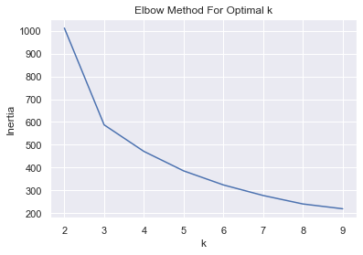

```python
plt.plot(K, inertia)
plt.xlabel('k')
plt.ylabel('Inertia')
plt.title('Elbow Method For Optimal k')
plt.show()
```

A clear 'elbow' can be seen at **K = 3**, however K = 4 also demonstrates that it may yield an effective solution. Although the solution of **K = 3** seems like a suitable choice and is most likely the optimal solution, an argument could be made for K = 4 and confirming the correct number of clusters at this stage is critical to the process. For this reason, further analysis was completed, in the form of a Silhouette score analysis.

### The Silhoutte Method

The Silhouette method uses Silhouette Score analysis to produce a plot which again can be interpretted visually, on it's own, it is much harder to interpret than a plot derived using the elbow method, however when combined with the elbow plot, it allows a much larger insight into the estimate of the optimal number of clusters.

The Silhouette method calculates a score for each iteration of the process and each value of K (again where K is the number of clusters).  
These values lie between -1 and 1. Where:  
1 : instance is well inside own cluster, far from other clusters - meaning correct assignment.  
0 : near boundary of cluster  
-1 : instance is outside cluster therefore assigned to wrong cluster

The silhouette score is the mean silhouette of all of the instances.  
The Silhouette Coefficient is (b-a)/ max(a,b)  
Where: a = The mean distance to other instances in the same cluster. (Mean Intracluster Distance) b = The mean "Nearest Cluster" distance. The mean distance to all instances of the next nearest cluster, which is defined by the cluster which minimises the value of b.

```python
#import
from sklearn.metrics import silhouette_score
#list to score metric from different k values.
s_score = []
#range to anlayse
K  = range(2,10)
for k in K:
    kmeans = KMeans(n_clusters = k)
    kmeans.fit(seedSet)
    s_score.append(silhouette_score(seedSet, kmeans.labels_))
```

This code first imports the necessary functions from the sklearn metrics library. A list is then created in which the Silhouette scores will be stored. Then the Silhouette score is calculated for each instance of K from 2 to 10. This is then plotted.

*N.B. The Silhouette Score Analysis graph will change slightly each time it is calculated due to the randomised starting value. However the Trend should stay approximately the same.*

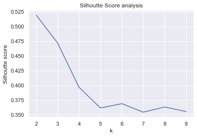

```python
#plotting
plt.plot(K, s_score)
plt.xlabel('k')
plt.ylabel('Silhoutte score')
plt.title('Silhoutte Score analysis')
plt.show()
```

# Investigating into the dataset

```python
samples = seedSet.values
```

```python
seedSet.describe()
```

|  | area | perimeter | compactness | length | width | asymmetry | groove length |
| --- | --- | --- | --- | --- | --- | --- | --- |
| count | 210.000000 | 210.000000 | 210.000000 | 210.000000 | 210.000000 | 210.000000 | 210.000000 |
| mean | 14.847524 | 14.559286 | 0.871000 | 5.628533 | 3.258605 | 3.700200 | 5.408071 |
| std | 2.909699 | 1.305959 | 0.023594 | 0.443063 | 0.377714 | 1.503559 | 0.491480 |
| min | 10.590000 | 12.410000 | 0.808000 | 4.899000 | 2.630000 | 0.765000 | 4.519000 |
| 25% | 12.270000 | 13.450000 | 0.857250 | 5.262250 | 2.944000 | 2.561500 | 5.045000 |
| 50% | 14.355000 | 14.320000 | 0.873500 | 5.523500 | 3.237000 | 3.599000 | 5.223000 |
| 75% | 17.305000 | 15.715000 | 0.887750 | 5.979750 | 3.561750 | 4.768750 | 5.877000 |
| max | 21.180000 | 17.250000 | 0.918000 | 6.675000 | 4.033000 | 8.456000 | 6.550000 |

This gives a small insight into the data and shows the sort of values that will be being handled, while it is not critical to the clustering process, more information about the data being used is always a good thing.

## Using the pearson's Correlation Coefficient

In order to determine which two attributes were to be used to compute the clustering, first the pairwise correlation of columns was calculated. This shows how closely each column is correlated to the comparative column, where 1.00 = exact match, 0 = no correlation, and -1 = perfect negative correlation (as one increases the other decreases).

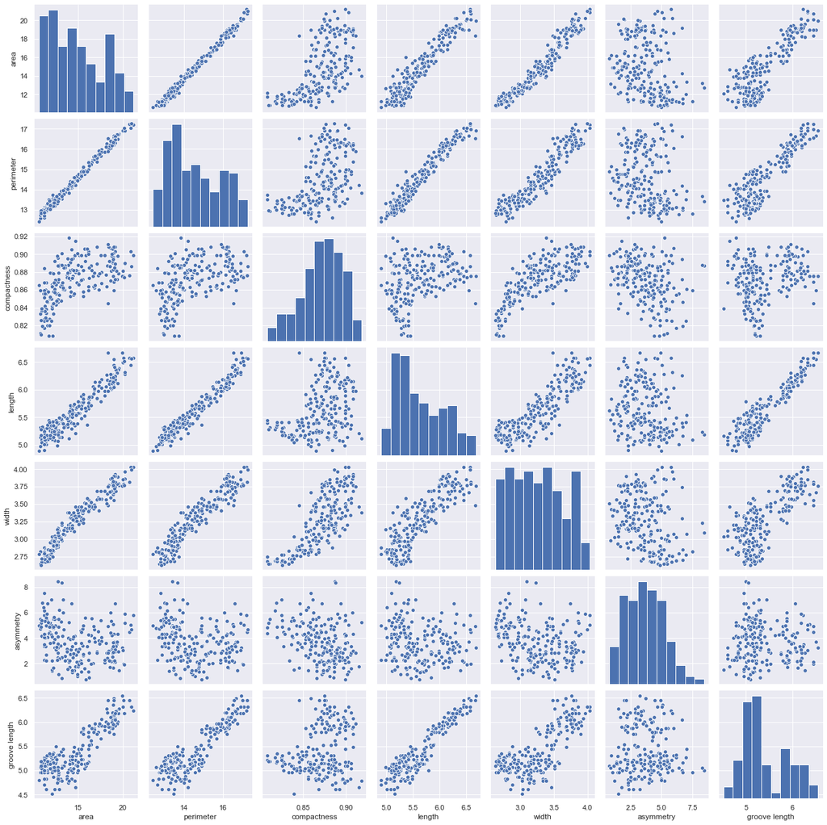

```python
sns.pairplot(seedSet)
```

This shows a visual representation of the correlation between each pair of variables, below shows the numerical values of the pearson correlation coefficient, displayed in a table format, where values are between 1 and -1, 1 being a perfect strong positive correlation, -1 being a perfect strong negative correlation, and 0 being no correlation.

The **pandas** function **".corr(method = 'pearson')"** will be used to compute an NxN table where N is the number of attributes. The table will be populated by the correlation value between the respective columns, calculated using the **"Pearson Correlation Coefficient"**

```python
seedSet.corr(method = 'pearson')
```

|  | area | perimeter | compactness | length | width | asymmetry | groove length |
| --- | --- | --- | --- | --- | --- | --- | --- |
| area | 1.000000 | 0.994341 | 0.609032 | 0.949985 | 0.970771 | -0.229572 | 0.863693 |
| perimeter | 0.994341 | 1.000000 | 0.530036 | 0.972422 | 0.944829 | -0.217340 | 0.890784 |
| compactness | 0.609032 | 0.530036 | 1.000000 | 0.368725 | 0.762159 | -0.332585 | 0.227654 |
| length | 0.949985 | 0.972422 | 0.368725 | 1.000000 | 0.860415 | -0.171562 | 0.932806 |
| width | 0.970771 | 0.944829 | 0.762159 | 0.860415 | 1.000000 | -0.258036 | 0.749131 |
| asymmetry | -0.229572 | -0.217340 | -0.332585 | -0.171562 | -0.258036 | 1.000000 | -0.011079 |
| groove length | 0.863693 | 0.890784 | 0.227654 | 0.932806 | 0.749131 | -0.011079 | 1.000000 |

As shown by the table, and further supported by the diagram, it is apparent that the area an perimeter share the strongest correlation, and assymetry coefficient and groove length share the weakest correlation. For this reason, the two dimensions chosen to be plotted on are perimeter vs area.

```python
#where x is data
kmeans = KMeans(n_clusters = 3) #definition of model
kmeans.fit(samples) #training
y_kmeans = kmeans.predict(samples) #predicting
```

```python
y_kmeans
```

```
array([1, 1, 1, 1, 1, 1, 1, 1, 1, 1, 1, 1, 1, 1, 1, 1, 2, 1, 1, 2, 1, 1,
       1, 1, 1, 1, 2, 1, 1, 1, 1, 1, 1, 1, 1, 1, 1, 0, 1, 2, 1, 1, 1, 1,
       1, 1, 1, 1, 1, 1, 1, 1, 1, 1, 1, 1, 1, 1, 1, 1, 2, 2, 2, 2, 1, 1,
       1, 1, 1, 2, 0, 0, 0, 0, 0, 0, 0, 0, 0, 0, 0, 0, 0, 0, 0, 0, 0, 0,
       0, 0, 0, 0, 0, 0, 0, 0, 0, 0, 0, 0, 1, 0, 0, 0, 0, 0, 0, 0, 0, 0,
       0, 0, 0, 0, 0, 0, 0, 0, 0, 0, 0, 0, 1, 0, 1, 0, 0, 0, 0, 0, 0, 0,
       1, 1, 1, 1, 0, 1, 1, 1, 2, 2, 2, 2, 2, 2, 2, 2, 2, 2, 2, 2, 2, 2,
       2, 2, 2, 2, 2, 2, 2, 2, 2, 2, 2, 2, 2, 2, 2, 2, 2, 2, 2, 2, 2, 2,
       2, 2, 2, 1, 2, 2, 2, 2, 2, 2, 2, 2, 2, 2, 2, 2, 2, 2, 2, 2, 2, 2,
       2, 2, 2, 1, 2, 2, 2, 2, 2, 2, 2, 2])
```

This is an output of the matrix formed by the predictive algorithm, it shows the predicted cluster for each Seed. There are 3 clusters, therefore values of 0, 1 and 2 are used to represent the three possible clusters.

**"y_kmeans"** is the name given to the property of the seed declaring which cluster it belongs to. (0,1,2).  
**Note:** The assigned cluster is just a number, and can therefore change each time the code is run, the content of the clusters themselves will always be the same, however the cluster number may change between runs. (E.G. Cluster 1 this time may be cluster 2 next run.)

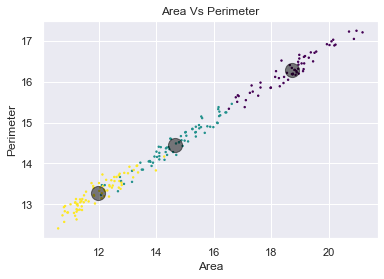

```python
plt.scatter(samples[:, 0], samples[:, 1], c=y_kmeans, s=2, cmap='viridis')
centers = kmeans.cluster_centers_
plt.scatter(centers[:,0],centers[:,1], c = 'black', s = 200, alpha = 0.5)
plt.xlabel('Area')
plt.ylabel('Perimeter')
plt.title('Area Vs Perimeter')
```

This shows how the clusters would be presented when plotted against the Area and Perimeter, the colours represent the different clusters. The colours do not represent an individual cluster, and are not permanently assigned to each respective cluster, however they are used to distinguish between the three clusters. The Black dot is used to indicate the centre of the cluster. While there appears to be three distinct clusters, a small overlap is also observable.

```python
from scipy.spatial.distance import cdist

def plot_kmeans(kmeans, x, n_clusters = 3, rseed=0, ax = None):
    labels = kmeans.fit_predict(x)

    ax = ax or plt.gca()
    ax.axis('equal')
    ax.scatter(x[:,0],x[:,1], c = labels, s =10, cmap = 'viridis', zorder = 2)

    # plot the representation of the kmeans model
    centers = kmeans.cluster_centers_
    radii = [cdist(x[labels == i], [center]).max()
            for i, center in enumerate(centers)]
    for c, r, in zip(centers, radii):
        ax.add_patch(plt.Circle(c,r,fc = '#CCCCCC', lw = 3, alpha=0.5, zorder = 1))
    plt.scatter(centers[:, 0], centers[:, 1], c='black', s=200, alpha=1);
    plt.xlabel('Area')
    plt.ylabel('Perimeter')
    plt.title('Area Vs Perimeter')
```

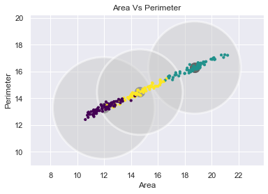

```python
kmeans = KMeans(n_clusters= 3, random_state = 0 )
plot_kmeans(kmeans, samples)
```

This is the same as the above graph however the sphere of influence of the cluster is also shown here.  
**Note**: The clustering was performed in all 7 dimensions, however can only be visualised in 2D therefore, there appears to be a significant overlap between the clusters when displayed in respect to the Area and Perimeter dimensions.

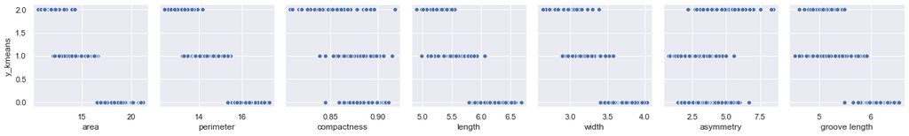

```python
clustered = seedSet
clustered['y_kmeans'] =  y_kmeans

sns.pairplot(clustered, y_vars = ['y_kmeans'], x_vars = ['area', 'perimeter', 'compactness', 'length', 'width', 'asymmetry', 'groove length'])
```

Where the Y axis shows the cluster assigned to each individual seed (0,1,2). (y_kmeans.) Shown above is the result of plotting the assigned cluster against each other variable, this gives an insight into which variables have the most effect on the overall cluster outcome, as well as showing the significance of the clustering. The more grouped the data is, and the further data is from data in a parallel cluster gives a good indication of the strength and accuracy of the clustering.  
From this we can infer that Compactness and asymmetry are significantly less important for determining which cluster the seed belongs to, when compared to variables such as area and perimeter.

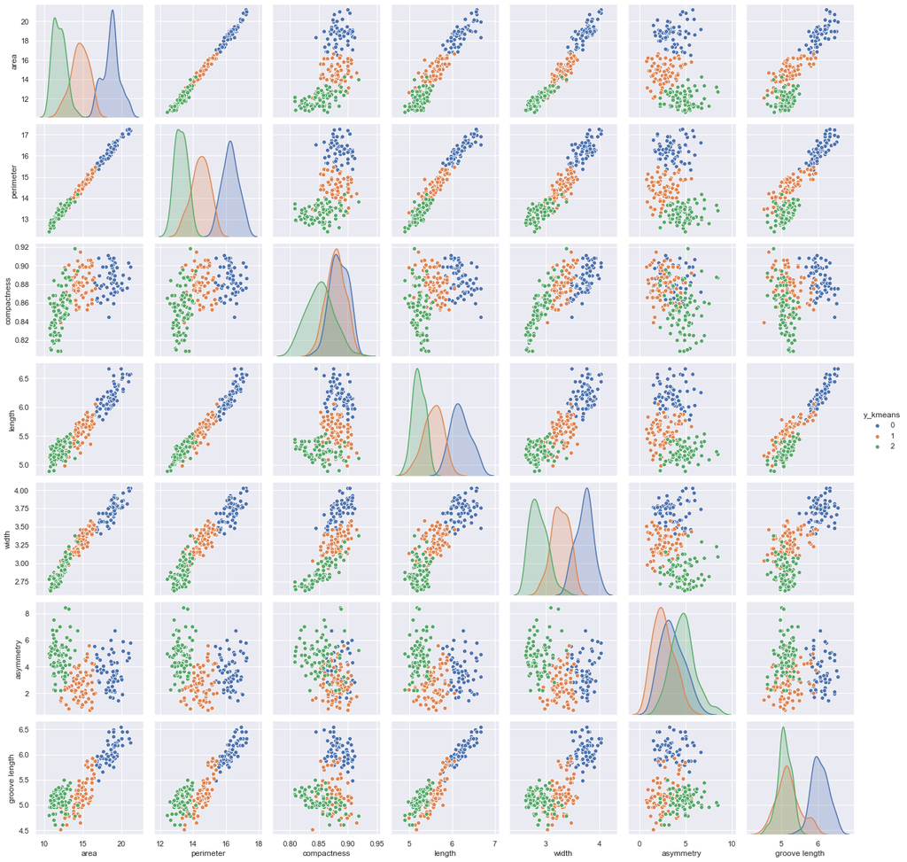

```python
sns.pairplot(clustered, hue= 'y_kmeans')
```

This is possibly the most crucial display, showing the effectiveness of the clusters against each pair of variables, essentially showing the quality of the clustering in all 7 dimensions. It shows the consistency of the clusting across the different groups and dimensions, as well as giving a strong insight into the impoortance of each variable when deciding the clusters.

# Mark Scheme: ✅❌

- An exceptional understanding of the principles of data modelling. ✅
- Professional use of modelling notation(s). ✅
- Excellent technical skills in implementing and testing a database model.✅
- Clear presentation of the coursework.✅
- Load the seeds.csv file into a Pandas data frame. ✅
- Explore the data, and find a way to cluster the seeds implementing one of the algorithms provided in the lectures. Visualise the results and explain why you have applied the method you have used. ✅

# Task 3 - Social Network Analysis

#### **Social network data**

This is an anonymised social network data set, that is stored in a CSV file. The edges are undirected, and each line of the file corresponds to an edge between two users (nodes) of the social network. Nodes are numbered from 1 to 2888.

Data sourced from: The Koblenz Network Collection, http://konect.uni-koblenz.de/ Use the social-network.csv data file provided in the CSGitLab Repository.

### Loading Dataset

Here the dataset is loaded. The **".info()"** function was used to establish information about the given data.

```python
import pandas as pd
BASE_DIR = 'D:/Users/Danny/FROM C/Desktop/Datasets'
socNet = pd.read_csv(BASE_DIR+'/social-network.csv', header =None)
socNet.info()
```

```
<class 'pandas.core.frame.DataFrame'>
RangeIndex: 2981 entries, 0 to 2980
Data columns (total 2 columns):
 #   Column  Non-Null Count  Dtype
---  ------  --------------  -----
 0   0       2981 non-null   int64
 1   1       2981 non-null   int64
dtypes: int64(2)
memory usage: 46.7 KB
```

This shows that there are **2981** entries, each with two attributes. It shows there is no missing data and no null values. It also shows that all data is in **'int64'** format. A key point to note is that there is no header to this data, so this must be explicitly stated in the 'read' otherwise the first edge in the edge list will be lost and taken as header information. Resulting in only 2980 entries being read.

### **Use Networkx to calculate statistics of the network, rather than implementing your own Python code to do so. The visualisation may be hard to interpret at first, experimenting with different settings for the layout may help.**

### Importing NetworkX

**"NetworkX** is a Python package for the creation, manipulation, and study of the structure, dynamics, and functions of complex networks."

For more information on the **NetworkX** library - see the official site and documentation: *https://networkx.org/documentation/stable/index.html*  
For the code and further information visit the GitHub Repository: *https://github.com/networkx/networkx*

```python
import networkx as nx
```

```python
with open(BASE_DIR+'/social-network.csv') as f:
    el = (list(map(int,l.split(','))) for l in f)
    g = nx.from_edgelist(el)
```

The Next step is to import the data into a network, the method of doing this is by iterating through the file, line by line, and creating a list of the data, with the data originally separated by commas now in separate columns in the list. This is then used as an Edgelist by NetworkX to create a graph.

More information can be obtained about the graph using the **NetworkX** functions. Some examples are as follows:

```python
g.number_of_nodes(), g.number_of_edges()
```

```
(2888, 2981)
```

This returns the number of nodes (left) and the number of edges (right) in the network.  
Here are some more functions which can be used to obtain more information. These have been commented out, as the output is not entirely necessary in the current context.

```python
#g.nodes()                                  #displays all of the nodes in network g
#nx.degree(g)                               #Returns a degree view of all nodes
#nx.degree(g,52)                            #Returns a degree view of single node
#nx.number_connected_components(g)          #Returns the number of connected components.
#nx.shortest_path(g, 52,5)                  #Returns the shortest path between two nodes
#nx.degree_histogram(g)                     #Returns a list of the frequency of each degree value
```

One very useful piece of information to know about the graph, is the diameter. The diameter of a graph is the maximum eccentricity of any vertex in the graph. It is the greatest distance between any pair of vertices. The diameter is found using **"nx.diameter(g)"**.

```python
nx.diameter(g)           #Returns the diameter of the graph G (Maximum distance between nodes)
```

```
9
```

The diameter of this graph is 9. This is significant because although there are 2888 nodes, the maximum edges required to be traversed to get from one none to the other is 9. This implies a high degree of connectivity on the network.

For Visual representations: matplotlib must be imported, and given permission to execute inline to display graphs in the notebook.

```python
%matplotlib inline
#sns.set_style("white")
import matplotlib.pyplot as plt
```

```python
cc = nx.clustering(g)                #Compute a clustering coefficient for nodes.
```

**NetworkX** function **".clustering(g)"** is used to compute a clustering coefficient for each node. The clustering coefficient is a measure of how interconnected the neighbours of each node are. This is Displayed below.

```python
cc
```

[output not shown]

[output cut: 986 more lines]

When Plotted into a histogram with two bins, almost representing a binary possibility of high/low clustering coefficient, it can be shown that the majority of the data has a low clustering coefficient while less than 150 have a clustering coefficient over 0.5 (High clustering coefficient).

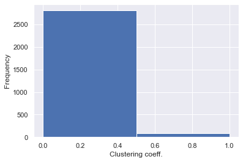

```python
plt.hist(list(cc.values()),bins=2)
plt.ylabel("Frequency")
plt.xlabel("Clustering coeff.")
```

```python
nx.betweenness_centrality(g)
```

[output not shown]

[output cut: 986 more lines]

```python
#plt.bar(nx.betweenness_centrality(g))
#plt.ylabel("Frequency")
#plt.xlabel("Betweenness_Centrality")
```

Betweenness Centrality is a measure of importance of a node in the network, in terms of possible paths through the network. It is calculated at the fraction of all shortest paths that would pass through that node. Nodes with a high BC often connect separate regions of the network, and are therefore of high importance to the functionality of the network. As these are fractions, they all lie between 0 and 1.  
From this we can infer that node 603 is the most interconnected (and subsequently likely most important) in the network.

The assortativity of a network is a measure for how strong the tendency for nodes to interact with other similar nodes is. The assortativity coefficient measures the correrelation of node degrees of interacting edges. Pos = high-high neg = high- low.

```python
nx.degree_assortativity_coefficient(g)
```

```
-0.6682140067239861
```

This would imply that the network is majority made up of central ndes which act as a hub branching out to less connected nodes.

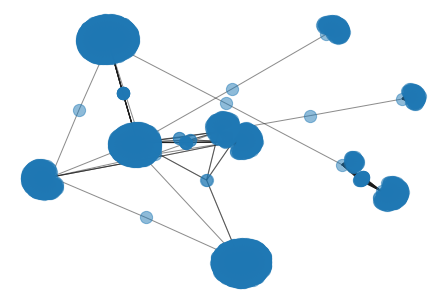

```python
G = g
layout = nx.spring_layout(G)
nx.draw(G,pos=layout,node_size=150,alpha=0.5)
```

The previous statement is further supported by this graph.

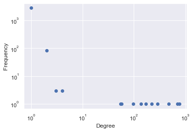

```python
ddist = nx.degree_histogram(G)[1:] # Skip 0 degree nodes
plt.loglog(range(1,len(ddist)+1),ddist,'o')
plt.xlabel("Degree")
plt.ylabel("Frequency")
```

This shows there is an extremely large amount of nodes with a low degree, and a small amount of nodes with an extremely high degree. This further supports the assortivity statement.

Now a Trial and error approach was taken in order to investigate the best layout for displaying the network. These have been rearranged into oder if usefulness.

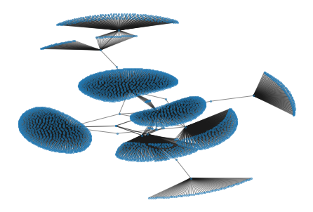

```python
layout = nx.kamada_kawai_layout(G)
nx.draw(G,pos=layout,node_size=5,alpha=0.5)
```

This is the "Kamada Kawai" representation, a force directed representation, calculated using Kamada-Kawai path-length cost-function.This is a useful representation of the data. It shows the Network as many strongly connected nodes acting as hubs for the less connected nodes, as suspected by the assortivity coefficient.

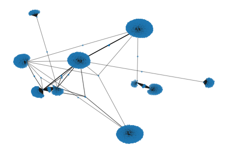

```python
layout = nx.fruchterman_reingold_layout(G)
nx.draw(G,pos=layout,node_size=5,alpha=0.5)
```

This graph represents the fruchterman-reingold layout of the network, this is possibly the most useful representation, this is another force-directed graph. by lowering the size of the node displayed, a much more visually interpretive view is available.

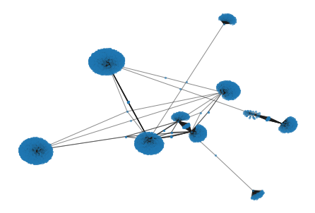

```python
layout = nx.spring_layout(G)
nx.draw(G,pos=layout,node_size=5,alpha=0.5)
```

The Spring layout is possibly one of the most common and effective ways to displaying graphs, it displays it in a logical and easy to interpret format, again a force-directed layout.

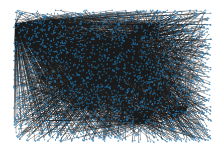

```python
layout = nx.random_layout(G)
nx.draw(G,pos=layout,node_size=5,alpha=0.5)
```

This is a random representation, this is of little-to-no use, however it does show the sheer volume of interconnectivity.

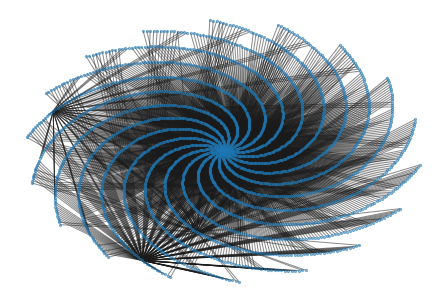

```python
layout = nx.spiral_layout(G)
nx.draw(G,pos=layout,node_size=5,alpha=0.5)
```

This is the spiral layout, while it effectievly demonstrates the volume of interconnectivity and looks extremely aesthetically appealing, it is hard to infer much useful information about the network.

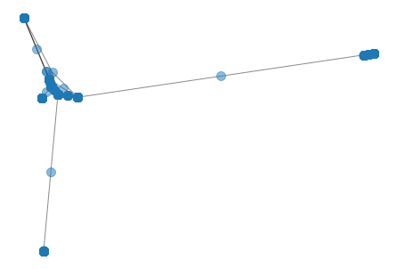

```python
layout = nx.spectral_layout(G)
nx.draw(G,pos=layout,node_size=100,alpha=0.5)
```

The spectral layout offers a small insight into the network, with a smaller network,the complexity and visual representation would be much more effective than with the current system. While this does give some information about the system it is not the most effective representation.

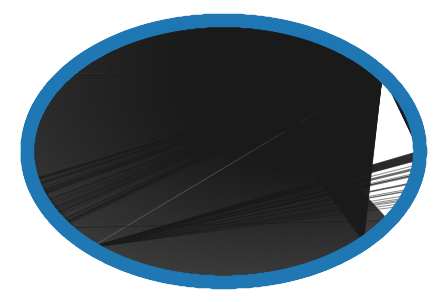

```python
layout = nx.circular_layout(G)
nx.draw(G,pos=layout,node_size=150,alpha=0.5)
```

This is the representation of the network in a circular layout, because of the sheer volume of edges (and nodes), this is not very clear or effective for displaying the relationships of the netwrok, other than showing the small section where there are few connections, this could be a useful view if it was scaled to be a larger image, however the size needed for this amount of data is unrealistic.

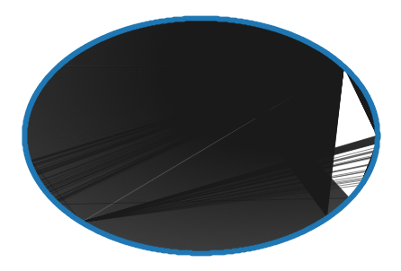

```python
layout = nx.shell_layout(G)
nx.draw(G,pos=layout,node_size=20,alpha=0.5)
```

This is a shell representation, similar to circular representation, if this was scaled to a size that it became interprettable this could be extrememly useful, but that size is not realistically applicable, so this is also not an effective representation due to the sheer volume of data.

**NetworkX** also includes more layouts, including bipartite, this was not deemed as suitable for this style of network. Planar layout was also not applicable as the data is not planar. Same with multivariate.